# COVID_19_Project

Kashan Ahmed

12/7/2021

### Importing Data:

Library in tidyverse package Importing Data Sets from Github repository of John Hopkins Website in url_in. Set file_names and concatenate all four files. Then string concatenate url_in and file_names in urls.

```r
library(tidyverse)
library(lubridate)
url_in <- "https://raw.githubusercontent.com/CSSEGISandDATA/COVID-19/master/csse_covid_19_data/csse_covid_19_time_series/"

file_names <- c("time_series_covid19_confirmed_global.csv",
                "time_series_covid19_deaths_global.csv",
                "time_series_covid19_confirmed_US.csv",
                "time_series_covid19_deaths_US.csv")
urls <- str_c(url_in,file_names)
```

Read Data-Sets and putting them in variable names.

```r
global_cases <- read_csv(urls[1])
global_deaths <- read_csv(urls[2])
US_cases <- read_csv(urls[3])
US_deaths <- read_csv(urls[4])
```

### Tidying and Transforming Data

We will pivot longer all columns except Province/State, Country/Region, Lat, Long. Change names_to = “date”, values_to = “cases” and remove Lat and Long. Join Global cases and Global deaths in Global.

```r
global_cases <- global_cases %>%
  pivot_longer(cols = -c(`Province/State`,
                         `Country/Region`, Lat, Long),
              names_to = "date",
              values_to = "cases") %>%
  select(-c(Lat, Long))

global_deaths <- global_deaths %>%
  pivot_longer(cols = -c(`Province/State`,
                         `Country/Region`, Lat, Long),
              names_to = "date",
              values_to = "deaths") %>%
  select(-c(Lat, Long))

global <- global_cases %>%
    full_join(global_deaths) %>%
    rename(Country_Region =`Country/Region`,
           Province_State = `Province/State`) %>%
    mutate(date = mdy(date))
global
```

```
## # A tibble: 192,080 × 5
##    Province_State Country_Region date       cases deaths
##    <chr>          <chr>          <date>     <dbl>  <dbl>
##  1 <NA>           Afghanistan    2020-01-22     0      0
##  2 <NA>           Afghanistan    2020-01-23     0      0
##  3 <NA>           Afghanistan    2020-01-24     0      0
##  4 <NA>           Afghanistan    2020-01-25     0      0
##  5 <NA>           Afghanistan    2020-01-26     0      0
##  6 <NA>           Afghanistan    2020-01-27     0      0
##  7 <NA>           Afghanistan    2020-01-28     0      0
##  8 <NA>           Afghanistan    2020-01-29     0      0
##  9 <NA>           Afghanistan    2020-01-30     0      0
## 10 <NA>           Afghanistan    2020-01-31     0      0
## # … with 192,070 more rows
```

```r
summary(global)
```

```
##  Province_State     Country_Region          date                cases
##  Length:192080      Length:192080      Min.   :2020-01-22   Min.   :       0
##  Class :character   Class :character   1st Qu.:2020-07-11   1st Qu.:     180
##  Mode  :character   Mode  :character   Median :2020-12-29   Median :    3275
##                                        Mean   :2020-12-29   Mean   :  354596
##                                        3rd Qu.:2021-06-19   3rd Qu.:   68616
##                                        Max.   :2021-12-07   Max.   :49387208
##      deaths
##  Min.   :     0
##  1st Qu.:     1
##  Median :    50
##  Mean   :  7874
##  3rd Qu.:  1207
##  Max.   :791514
```

Filter out Zero cases

```r
global <- global %>%  filter(cases > 0)
summary(global)
```

```
##  Province_State     Country_Region          date                cases
##  Length:175264      Length:175264      Min.   :2020-01-22   Min.   :       1
##  Class :character   Class :character   1st Qu.:2020-08-13   1st Qu.:     458
##  Mode  :character   Mode  :character   Median :2021-01-23   Median :    5538
##                                        Mean   :2021-01-20   Mean   :  388618
##                                        3rd Qu.:2021-07-02   3rd Qu.:   92772
##                                        Max.   :2021-12-07   Max.   :49387208
##      deaths
##  Min.   :     0
##  1st Qu.:     3
##  Median :    86
##  Mean   :  8629
##  3rd Qu.:  1639
##  Max.   :791514
```

Filter out cases more than 28000000

```r
global %>% filter(cases > 28000000)
```

```
## # A tibble: 485 × 5
##    Province_State Country_Region date          cases deaths
##    <chr>          <chr>          <date>        <dbl>  <dbl>
##  1 <NA>           India          2021-05-30 28047534 329100
##  2 <NA>           India          2021-05-31 28175044 331895
##  3 <NA>           India          2021-06-01 28307832 335102
##  4 <NA>           India          2021-06-02 28441986 337989
##  5 <NA>           India          2021-06-03 28574350 340702
##  6 <NA>           India          2021-06-04 28694879 344082
##  7 <NA>           India          2021-06-05 28809339 346759
##  8 <NA>           India          2021-06-06 28909975 349186
##  9 <NA>           India          2021-06-07 28996473 351309
## 10 <NA>           India          2021-06-08 29089069 353528
## # … with 475 more rows
```

Now we will work with US cases and do the same pivoting and joing deaths and cases in US.

```r
US_cases %>%
  pivot_longer(cols = -(UID:Combined_Key),
              names_to = "date",
              values_to = "cases")
```

```
## # A tibble: 2,292,612 × 13
##         UID iso2  iso3  code3  FIPS Admin2  Province_State Country_Region   Lat
##       <dbl> <chr> <chr> <dbl> <dbl> <chr>   <chr>          <chr>          <dbl>
##  1 84001001 US    USA     840  1001 Autauga Alabama        US              32.5
##  2 84001001 US    USA     840  1001 Autauga Alabama        US              32.5
##  3 84001001 US    USA     840  1001 Autauga Alabama        US              32.5
##  4 84001001 US    USA     840  1001 Autauga Alabama        US              32.5
##  5 84001001 US    USA     840  1001 Autauga Alabama        US              32.5
##  6 84001001 US    USA     840  1001 Autauga Alabama        US              32.5
##  7 84001001 US    USA     840  1001 Autauga Alabama        US              32.5
##  8 84001001 US    USA     840  1001 Autauga Alabama        US              32.5
##  9 84001001 US    USA     840  1001 Autauga Alabama        US              32.5
## 10 84001001 US    USA     840  1001 Autauga Alabama        US              32.5
## # … with 2,292,602 more rows, and 4 more variables: Long_ <dbl>,
## #   Combined_Key <chr>, date <chr>, cases <dbl>
```

```r
US_cases <- US_cases %>%
  pivot_longer(cols = -(UID:Combined_Key),
              names_to = "date",
              values_to = "cases") %>%
  select(Admin2:cases) %>%
  mutate(date = mdy(date)) %>%
  select(-c(Lat, Long_))

US_deaths <- US_deaths %>%
  pivot_longer(cols = -(UID:Population),
              names_to = "date",
              values_to = "deaths") %>%
  select(Admin2:deaths) %>%
  mutate(date = mdy(date)) %>%
  select(-c(Lat, Long_))

US <- US_cases %>%
    full_join(US_deaths)
```

further wrangling global

```r
global <- global %>%
  unite("Combined_Key",
        c(Province_State, Country_Region),
        sep = ",",
        na.rm = TRUE,
        remove = FALSE)
global
```

```
## # A tibble: 175,264 × 6
##    Combined_Key Province_State Country_Region date       cases deaths
##    <chr>        <chr>          <chr>          <date>     <dbl>  <dbl>
##  1 Afghanistan  <NA>           Afghanistan    2020-02-24     5      0
##  2 Afghanistan  <NA>           Afghanistan    2020-02-25     5      0
##  3 Afghanistan  <NA>           Afghanistan    2020-02-26     5      0
##  4 Afghanistan  <NA>           Afghanistan    2020-02-27     5      0
##  5 Afghanistan  <NA>           Afghanistan    2020-02-28     5      0
##  6 Afghanistan  <NA>           Afghanistan    2020-02-29     5      0
##  7 Afghanistan  <NA>           Afghanistan    2020-03-01     5      0
##  8 Afghanistan  <NA>           Afghanistan    2020-03-02     5      0
##  9 Afghanistan  <NA>           Afghanistan    2020-03-03     5      0
## 10 Afghanistan  <NA>           Afghanistan    2020-03-04     5      0
## # … with 175,254 more rows
```

Adding Population Data

```r
uid_lookup_url <- "https://raw.githubusercontent.com/CSSEGISandData/COVID-19/master/csse_covid_19_data/UID_ISO_FIPS_LookUp_Table.csv"
uid <- read_csv(uid_lookup_url) %>%
    select(-c(Lat, Long_, Combined_Key, code3, iso2, iso3, Admin2))
global <-global %>%
  left_join(uid, by = c("Province_State", "Country_Region")) %>%
  select(-c(UID, FIPS)) %>%
  select (Province_State, Country_Region, date,
          cases, deaths, Population,
          Combined_Key)
global
```

```
## # A tibble: 175,264 × 7
##    Province_State Country_Region date       cases deaths Population Combined_Key
##    <chr>          <chr>          <date>     <dbl>  <dbl>      <dbl> <chr>
##  1 <NA>           Afghanistan    2020-02-24     5      0   38928341 Afghanistan
##  2 <NA>           Afghanistan    2020-02-25     5      0   38928341 Afghanistan
##  3 <NA>           Afghanistan    2020-02-26     5      0   38928341 Afghanistan
##  4 <NA>           Afghanistan    2020-02-27     5      0   38928341 Afghanistan
##  5 <NA>           Afghanistan    2020-02-28     5      0   38928341 Afghanistan
##  6 <NA>           Afghanistan    2020-02-29     5      0   38928341 Afghanistan
##  7 <NA>           Afghanistan    2020-03-01     5      0   38928341 Afghanistan
##  8 <NA>           Afghanistan    2020-03-02     5      0   38928341 Afghanistan
##  9 <NA>           Afghanistan    2020-03-03     5      0   38928341 Afghanistan
## 10 <NA>           Afghanistan    2020-03-04     5      0   38928341 Afghanistan
## # … with 175,254 more rows
```

### Analysing and Visualizing Data

```r
US_by_state <- US %>%
  group_by(Province_State, Country_Region, date) %>%
  summarize(cases = sum(cases), deaths = sum(deaths),
            Population = sum(Population)) %>%
  mutate(deaths_per_mill = deaths * 1000000/Population) %>%
  select(Province_State, Country_Region, date,
         cases, deaths, deaths_per_mill, Population) %>%
  ungroup()
US_totals <- US_by_state %>%
    group_by(Country_Region, date) %>%
   summarize (cases = sum(cases), deaths = sum(deaths),
              Population = sum(Population)) %>%
   mutate(deaths_per_mill = deaths * 1000000/Population) %>%
  select(Country_Region, date,
         cases, deaths, deaths_per_mill, Population) %>%
  ungroup()
US_totals
```

```
## # A tibble: 686 × 6
##    Country_Region date       cases deaths deaths_per_mill Population
##    <chr>          <date>     <dbl>  <dbl>           <dbl>      <dbl>
##  1 US             2020-01-22     1      1         0.00300  332875137
##  2 US             2020-01-23     1      1         0.00300  332875137
##  3 US             2020-01-24     2      1         0.00300  332875137
##  4 US             2020-01-25     2      1         0.00300  332875137
##  5 US             2020-01-26     5      1         0.00300  332875137
##  6 US             2020-01-27     5      1         0.00300  332875137
##  7 US             2020-01-28     5      1         0.00300  332875137
##  8 US             2020-01-29     6      1         0.00300  332875137
##  9 US             2020-01-30     6      1         0.00300  332875137
## 10 US             2020-01-31     8      1         0.00300  332875137
## # … with 676 more rows
```

Covid-19 in US

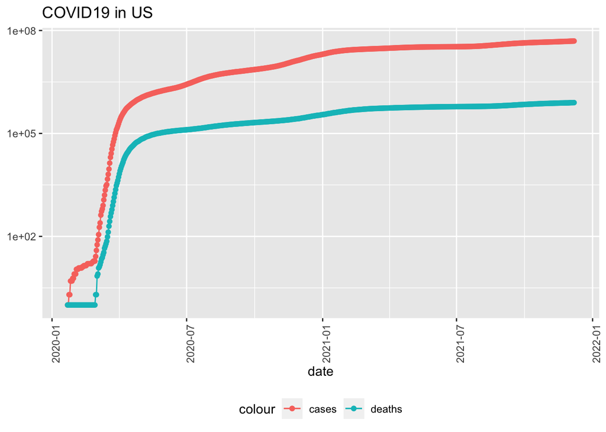

```r
US_totals %>%
  filter(cases>0) %>%
  ggplot(aes(x = date, y = cases))+
  geom_line(aes(color = "cases"))+
  geom_point(aes(color = "cases"))+
  geom_line(aes(y = deaths, color = "deaths"))+
  geom_point(aes(y = deaths, color = "deaths"))+
  scale_y_log10() +
  theme(legend.position = "bottom",
        axis.text.x = element_text(angle = 90))+
  labs(title = "COVID19 in US", y = NULL)
```

Covid-19 in Virginia

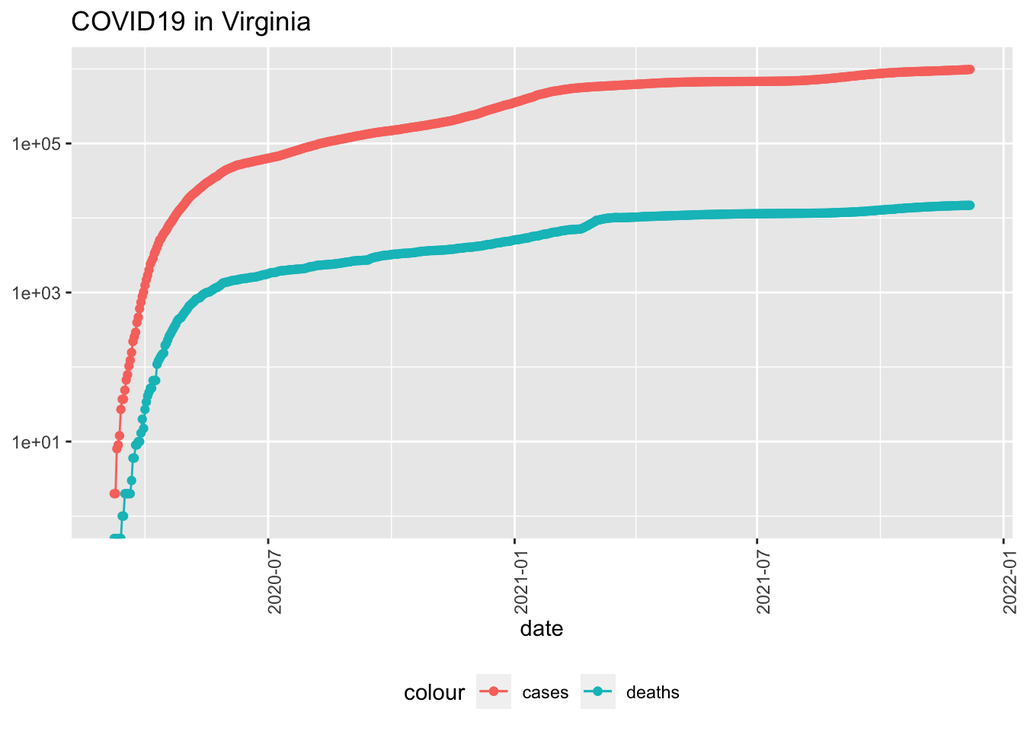

```r
state <- "Virginia"
US_by_state %>%
  filter(Province_State == state) %>%
  filter(cases > 0) %>%
  ggplot(aes(x = date, y = cases))+
  geom_line(aes(color = "cases"))+
  geom_point(aes(color = "cases"))+
  geom_line(aes(y = deaths, color = "deaths"))+
  geom_point(aes(y=deaths, color = "deaths"))+
  scale_y_log10()+
  theme(legend.position = "bottom",
        axis.text.x = element_text(angle = 90))+
  labs(title = str_c("COVID19 in ",state), y = NULL)
```

Covid-19 in Pakistan

```r
global_totals<- global %>%
    group_by(Country_Region, date) %>%
   summarize (cases = sum(cases), deaths = sum(deaths),
              Population = sum(Population)) %>%
   mutate(deaths_per_mill = deaths * 1000000/Population) %>%
  select(Country_Region, date,
         cases, deaths, deaths_per_mill, Population) %>%
  ungroup()
global_totals
```

```
## # A tibble: 122,764 × 6
##    Country_Region date       cases deaths deaths_per_mill Population
##    <chr>          <date>     <dbl>  <dbl>           <dbl>      <dbl>
##  1 Afghanistan    2020-02-24     5      0               0   38928341
##  2 Afghanistan    2020-02-25     5      0               0   38928341
##  3 Afghanistan    2020-02-26     5      0               0   38928341
##  4 Afghanistan    2020-02-27     5      0               0   38928341
##  5 Afghanistan    2020-02-28     5      0               0   38928341
##  6 Afghanistan    2020-02-29     5      0               0   38928341
##  7 Afghanistan    2020-03-01     5      0               0   38928341
##  8 Afghanistan    2020-03-02     5      0               0   38928341
##  9 Afghanistan    2020-03-03     5      0               0   38928341
## 10 Afghanistan    2020-03-04     5      0               0   38928341
## # … with 122,754 more rows
```

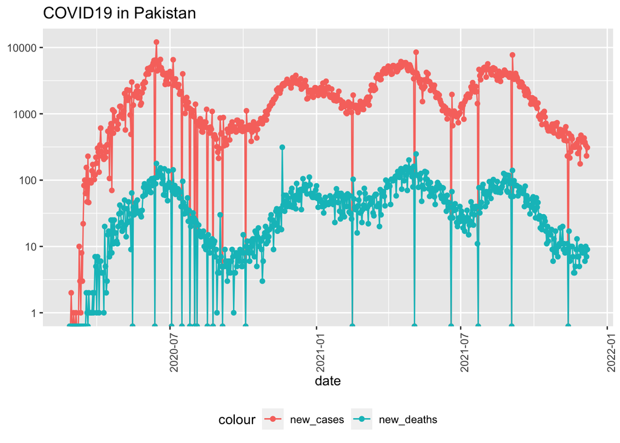

```r
Global_by_country <- global %>%
    mutate(new_cases = cases - lag(cases),
          new_deaths = deaths - lag(deaths))
global_totals <- global_totals %>%
  mutate(new_cases = cases - lag(cases),
          new_deaths = deaths - lag(deaths))

country <- "Pakistan"
Global_by_country %>%
  filter(Country_Region == country) %>%
  filter(cases > 0) %>%
  ggplot(aes(x = date, y = new_cases))+
  geom_line(aes(color = "new_cases"))+
  geom_point(aes(color = "new_cases"))+
  geom_line(aes(y = new_deaths, color = "new_deaths"))+
  geom_point(aes(y= new_deaths, color = "new_deaths"))+
  scale_y_log10()+
  theme(legend.position = "bottom",
        axis.text.x = element_text(angle = 90))+
  labs(title = str_c("COVID19 in ",country), y = NULL)
```

```r
US_by_state <- US_by_state %>%
    mutate(new_cases = cases - lag(cases),
          new_deaths = deaths - lag(deaths))
US_totals <- US_totals %>%
  mutate(new_cases = cases - lag(cases),
          new_deaths = deaths - lag(deaths))

tail(US_totals %>%  select(new_cases, new_deaths, everything()))
```

```
## # A tibble: 6 × 8
##   new_cases new_deaths Country_Region date          cases deaths deaths_per_mill
##       <dbl>      <dbl> <chr>          <date>        <dbl>  <dbl>           <dbl>
## 1    140875       3801 US             2021-12-02 48832234 786323           2362.
## 2    157899       1532 US             2021-12-03 48990133 787855           2367.
## 3     61013        507 US             2021-12-04 49051146 788362           2368.
## 4     34215        161 US             2021-12-05 49085361 788523           2369.
## 5    192917       1382 US             2021-12-06 49278278 789905           2373.
## 6    108930       1609 US             2021-12-07 49387208 791514           2378.
## # … with 1 more variable: Population <dbl>
```

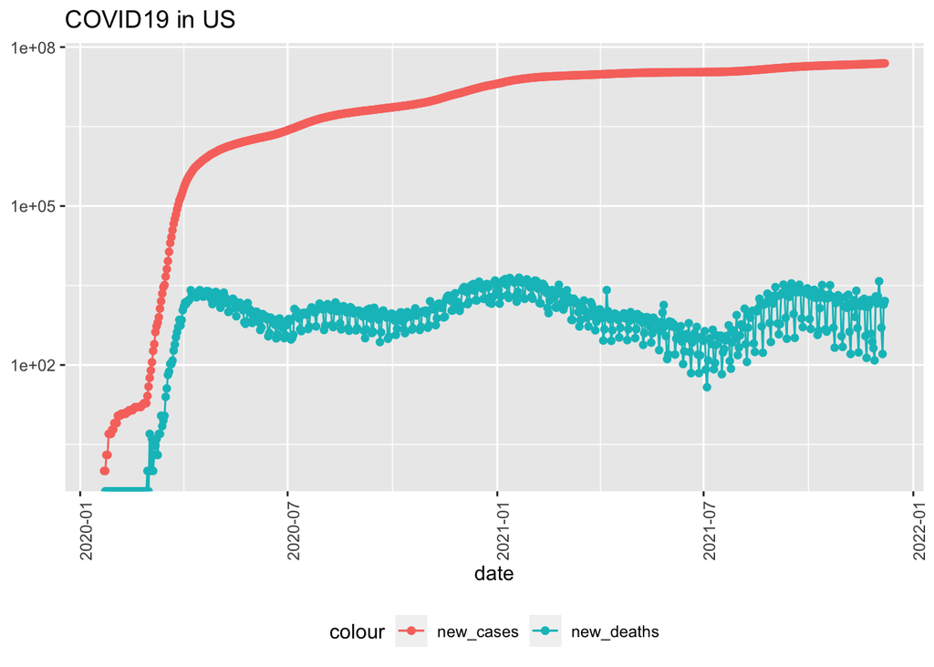

```r
US_totals %>%
  ggplot(aes(x = date, y = cases))+
  geom_line(aes(color = "new_cases"))+
  geom_point(aes(color = "new_cases"))+
  geom_line(aes(y = new_deaths, color = "new_deaths"))+
  geom_point(aes(y = new_deaths, color = "new_deaths"))+
  scale_y_log10()+
  theme(legend.position = "bottom",
        axis.text.x = element_text(angle = 90))+
  labs(title = ("COVID19 in US"), y = NULL)
```

new case in Virginia

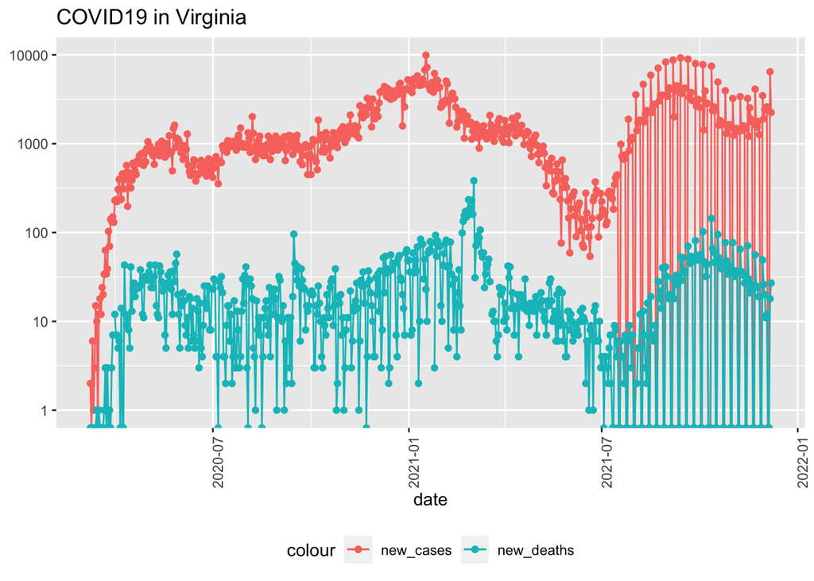

```r
state <- "Virginia"
US_by_state %>%
  filter(Province_State == state) %>%
  filter(cases > 0) %>%
  ggplot(aes(x = date, y = new_cases))+
  geom_line(aes(color = "new_cases"))+
  geom_point(aes(color = "new_cases"))+
  geom_line(aes(y = new_deaths, color = "new_deaths"))+
  geom_point(aes(y= new_deaths, color = "new_deaths"))+
  scale_y_log10()+
  theme(legend.position = "bottom",
        axis.text.x = element_text(angle = 90))+
  labs(title = str_c("COVID19 in ",state), y = NULL)
```

Global cases Covid-19 cases

```r
global_totals<- global %>%
    group_by(Country_Region, date) %>%
   summarize (cases = sum(cases), deaths = sum(deaths),
              Population = sum(Population)) %>%
   mutate(deaths_per_mill = deaths * 1000000/Population) %>%
  select(Country_Region, date,
         cases, deaths, deaths_per_mill, Population) %>%
  ungroup()
global_totals
```

```
## # A tibble: 122,764 × 6
##    Country_Region date       cases deaths deaths_per_mill Population
##    <chr>          <date>     <dbl>  <dbl>           <dbl>      <dbl>
##  1 Afghanistan    2020-02-24     5      0               0   38928341
##  2 Afghanistan    2020-02-25     5      0               0   38928341
##  3 Afghanistan    2020-02-26     5      0               0   38928341
##  4 Afghanistan    2020-02-27     5      0               0   38928341
##  5 Afghanistan    2020-02-28     5      0               0   38928341
##  6 Afghanistan    2020-02-29     5      0               0   38928341
##  7 Afghanistan    2020-03-01     5      0               0   38928341
##  8 Afghanistan    2020-03-02     5      0               0   38928341
##  9 Afghanistan    2020-03-03     5      0               0   38928341
## 10 Afghanistan    2020-03-04     5      0               0   38928341
## # … with 122,754 more rows
```

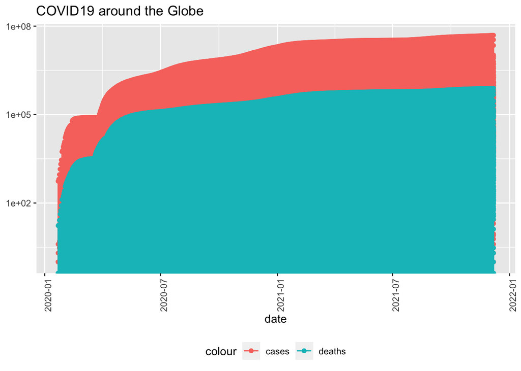

```r
 global_totals%>%
  filter(cases>0) %>%
  ggplot(aes(x = date, y = cases))+
  geom_line(aes(color = "cases"))+
  geom_point(aes(color = "cases"))+
  geom_line(aes(y = deaths, color = "deaths"))+
  geom_point(aes(y = deaths, color = "deaths"))+
  scale_y_log10() +
  theme(legend.position = "bottom",
        axis.text.x = element_text(angle = 90))+
  labs(title = "COVID19 around the Globe", y = NULL)
```

### Analysing and Modeling Data

```r
US_state_totals <- US_by_state %>%
  group_by(Province_State) %>%
  summarize(deaths = max(deaths), cases = max(cases),
            population = max(Population),
            cases_per_thou = 1000*cases/population,
            deaths_per_thou = 1000 * deaths/population) %>%
  filter(cases > 0, population > 0)

US_state_totals %>%
  slice_min(deaths_per_thou, n = 10) %>%
select(deaths_per_thou,cases_per_thou,everything())
```

```
## # A tibble: 10 × 6
##    deaths_per_thou cases_per_thou Province_State        deaths  cases population
##              <dbl>          <dbl> <chr>                  <dbl>  <dbl>      <dbl>
##  1          0               0.180 American Samoa             0     10      55641
##  2          0.0544          7.16  Northern Mariana Isl…      3    395      55144
##  3          0.671          85.6   Vermont                  419  53431     623989
##  4          0.730          62.5   Hawaii                  1033  88440    1415872
##  5          0.811          70.6   Virgin Islands            87   7569     107268
##  6          0.872          50.4   Puerto Rico             3274 189338    3754939
##  7          1.00           92.3   Maine                   1348 124098    1344212
##  8          1.12          189.    Utah                    3606 606531    3205958
##  9          1.19          206.    Alaska                   883 152537     740995
## 10          1.24          103.    Washington              9460 786042    7614893
```

```r
US_state_totals %>%
  slice_max(deaths_per_thou, n = 10) %>%
select(deaths_per_thou,cases_per_thou,everything())
```

```
## # A tibble: 10 × 6
##    deaths_per_thou cases_per_thou Province_State deaths   cases population
##              <dbl>          <dbl> <chr>           <dbl>   <dbl>      <dbl>
##  1            3.46           174. Mississippi     10306  517138    2976149
##  2            3.30           173. Alabama         16199  849409    4903185
##  3            3.21           144. New Jersey      28494 1279667    8882190
##  4            3.19           167. Louisiana       14844  774181    4648794
##  5            3.13           178. Arizona         22761 1298091    7278717
##  6            3.04           171. Oklahoma        12028  675733    3956971
##  7            2.98           144. New York        57880 2796990   19453561
##  8            2.91           177. Arkansas         8776  534590    3017804
##  9            2.89           158. Georgia         30724 1673082   10617423
## 10            2.88           174. Florida         61789 3741058   21477737
```

modeling

```r
mod <- lm(deaths_per_thou ~ cases_per_thou, data = US_state_totals)
summary(mod)
```

```
##
## Call:
## lm(formula = deaths_per_thou ~ cases_per_thou, data = US_state_totals)
##
## Residuals:
##     Min      1Q  Median      3Q     Max
## -1.7762 -0.2990 -0.0229  0.3418  1.0721
##
## Coefficients:
##                Estimate Std. Error t value Pr(>|t|)
## (Intercept)    0.195790   0.253681   0.772    0.444
## cases_per_thou 0.013466   0.001679   8.022 9.07e-11 ***
## ---
## Signif. codes:  0 '***' 0.001 '**' 0.01 '*' 0.05 '.' 0.1 ' ' 1
##
## Residual standard error: 0.5659 on 54 degrees of freedom
## Multiple R-squared:  0.5438, Adjusted R-squared:  0.5353
## F-statistic: 64.36 on 1 and 54 DF,  p-value: 9.075e-11
```

```r
US_state_totals %>% mutate(pred = predict(mod))
```

```
## # A tibble: 56 × 7
##    Province_State  deaths  cases population cases_per_thou deaths_per_thou  pred
##    <chr>            <dbl>  <dbl>      <dbl>          <dbl>           <dbl> <dbl>
##  1 Alabama          16199 8.49e5    4903185        173.               3.30 2.53
##  2 Alaska             883 1.53e5     740995        206.               1.19 2.97
##  3 American Samoa       0 1   e1      55641          0.180            0    0.198
##  4 Arizona          22761 1.30e6    7278717        178.               3.13 2.60
##  5 Arkansas          8776 5.35e5    3017804        177.               2.91 2.58
##  6 California       74953 5.13e6   39512223        130.               1.90 1.94
##  7 Colorado          9465 8.47e5    5758736        147.               1.64 2.18
##  8 Connecticut       8945 4.33e5    3565287        121.               2.51 1.83
##  9 Delaware          2203 1.57e5     973764        161.               2.26 2.37
## 10 District of Co…   1197 6.81e4     705749         96.5              1.70 1.50
## # … with 46 more rows
```

```r
US_tot_w_pred <- US_state_totals %>% mutate (pred = predict(mod))
US_tot_w_pred
```

```
## # A tibble: 56 × 7
##    Province_State  deaths  cases population cases_per_thou deaths_per_thou  pred
##    <chr>            <dbl>  <dbl>      <dbl>          <dbl>           <dbl> <dbl>
##  1 Alabama          16199 8.49e5    4903185        173.               3.30 2.53
##  2 Alaska             883 1.53e5     740995        206.               1.19 2.97
##  3 American Samoa       0 1   e1      55641          0.180            0    0.198
##  4 Arizona          22761 1.30e6    7278717        178.               3.13 2.60
##  5 Arkansas          8776 5.35e5    3017804        177.               2.91 2.58
##  6 California       74953 5.13e6   39512223        130.               1.90 1.94
##  7 Colorado          9465 8.47e5    5758736        147.               1.64 2.18
##  8 Connecticut       8945 4.33e5    3565287        121.               2.51 1.83
##  9 Delaware          2203 1.57e5     973764        161.               2.26 2.37
## 10 District of Co…   1197 6.81e4     705749         96.5              1.70 1.50
## # … with 46 more rows
```

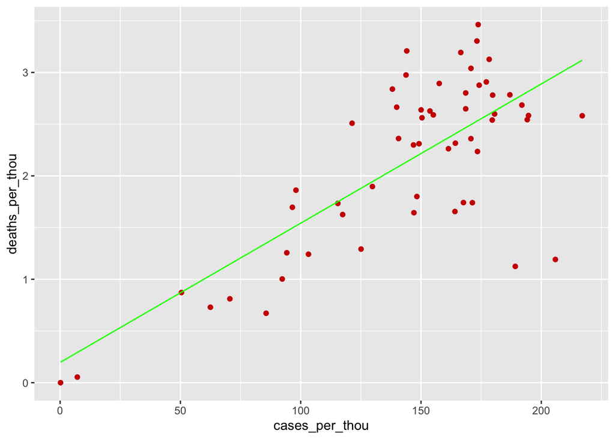

```r
US_tot_w_pred %>% ggplot() +
  geom_point(aes(x = cases_per_thou, y = deaths_per_thou), color = "red3")+
   geom_line(aes(x = cases_per_thou, y = pred), color = "green")
```

Global Data Modeled

```r
Global_bycountry_totals <- Global_by_country %>%
  group_by(Country_Region) %>%
  summarize(deaths = max(deaths), cases = max(cases),
            population = max(Population),
            cases_per_thou = 1000*cases/population,
            deaths_per_thou = 1000 * deaths/population) %>%
  filter(cases > 0, population > 0)

Global_bycountry_totals %>%
  slice_min(deaths_per_thou, n = 10) %>%
  select(deaths_per_thou,cases_per_thou,everything())
```

```
## # A tibble: 10 × 6
##    deaths_per_thou cases_per_thou Country_Region   deaths cases population
##              <dbl>          <dbl> <chr>             <dbl> <dbl>      <dbl>
##  1         0             33.4     Holy See              0    27        809
##  2         0              0.0170  Kiribati              0     2     117606
##  3         0              0.0685  Marshall Islands      0     4      58413
##  4         0              0.00879 Micronesia            0     1     113815
##  5         0              0.444   Palau                 0     8      18008
##  6         0              0.0153  Samoa                 0     3     196130
##  7         0              0.0306  Solomon Islands       0    20     652858
##  8         0              0.00946 Tonga                 0     1     105697
##  9         0.00320        1.73    Burundi              38 20523   11890781
## 10         0.00342        0.0205  Vanuatu               1     6     292680
```

```r
mod2 <- lm(deaths_per_thou ~ cases_per_thou, data = Global_bycountry_totals)
summary(mod2)
```

```
##
## Call:
## lm(formula = deaths_per_thou ~ cases_per_thou, data = Global_bycountry_totals)
##
## Residuals:
##     Min      1Q  Median      3Q     Max
## -1.9011 -0.2367 -0.1734  0.1446  5.0551
##
## Coefficients:
##                Estimate Std. Error t value Pr(>|t|)
## (Intercept)    0.211368   0.075684   2.793  0.00576 **
## cases_per_thou 0.012376   0.000906  13.660  < 2e-16 ***
## ---
## Signif. codes:  0 '***' 0.001 '**' 0.01 '*' 0.05 '.' 0.1 ' ' 1
##
## Residual standard error: 0.7488 on 189 degrees of freedom
## Multiple R-squared:  0.4968, Adjusted R-squared:  0.4941
## F-statistic: 186.6 on 1 and 189 DF,  p-value: < 2.2e-16
```

```r
Global_bycountry_totals%>%  slice_max(cases_per_thou)
```

```
## # A tibble: 1 × 6
##   Country_Region deaths  cases population cases_per_thou deaths_per_thou
##   <chr>           <dbl>  <dbl>      <dbl>          <dbl>           <dbl>
## 1 Montenegro       2334 158838     628062           253.            3.72
```

```r
Global_bycountry_totals%>% mutate(pred = predict(mod2))
```

```
## # A tibble: 191 × 7
##    Country_Region  deaths  cases population cases_per_thou deaths_per_thou  pred
##    <chr>            <dbl>  <dbl>      <dbl>          <dbl>           <dbl> <dbl>
##  1 Afghanistan       7317 1.58e5   38928341           4.05          0.188  0.261
##  2 Albania           3122 2.02e5    2877800          70.3           1.08   1.08
##  3 Algeria           6114 2.12e5   43851043           4.83          0.139  0.271
##  4 Andorra            133 1.88e4      77265         244.            1.72   3.23
##  5 Angola            1735 6.53e4   32866268           1.99          0.0528 0.236
##  6 Antigua and Ba…    117 4.15e3      97928          42.4           1.19   0.736
##  7 Argentina       116703 5.35e6   45195777         118.            2.58   1.68
##  8 Armenia           7718 3.41e5    2963234         115.            2.60   1.64
##  9 Australia         1390 1.31e5    8118000          16.2           0.171  0.412
## 10 Austria          12921 1.21e6    9006400         134.            1.43   1.87
## # … with 181 more rows
```

```r
Global_tot_w_pred <- Global_bycountry_totals %>% mutate (pred = predict(mod2))
Global_tot_w_pred
```

```
## # A tibble: 191 × 7
##    Country_Region  deaths  cases population cases_per_thou deaths_per_thou  pred
##    <chr>            <dbl>  <dbl>      <dbl>          <dbl>           <dbl> <dbl>
##  1 Afghanistan       7317 1.58e5   38928341           4.05          0.188  0.261
##  2 Albania           3122 2.02e5    2877800          70.3           1.08   1.08
##  3 Algeria           6114 2.12e5   43851043           4.83          0.139  0.271
##  4 Andorra            133 1.88e4      77265         244.            1.72   3.23
##  5 Angola            1735 6.53e4   32866268           1.99          0.0528 0.236
##  6 Antigua and Ba…    117 4.15e3      97928          42.4           1.19   0.736
##  7 Argentina       116703 5.35e6   45195777         118.            2.58   1.68
##  8 Armenia           7718 3.41e5    2963234         115.            2.60   1.64
##  9 Australia         1390 1.31e5    8118000          16.2           0.171  0.412
## 10 Austria          12921 1.21e6    9006400         134.            1.43   1.87
## # … with 181 more rows
```

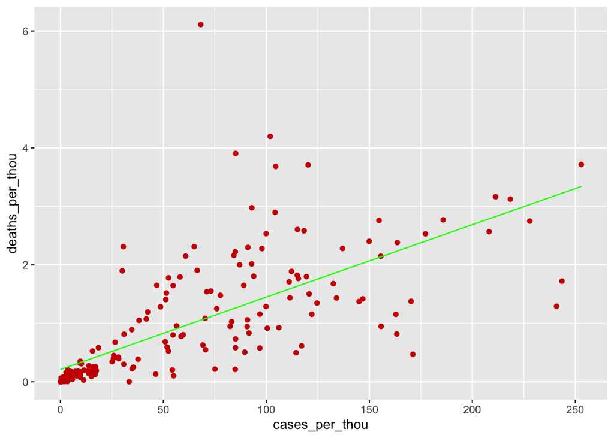

```r
Global_tot_w_pred %>% ggplot() +
  geom_point(aes(x = cases_per_thou, y = deaths_per_thou), color = "red3")+
  geom_line(aes(x = cases_per_thou, y = pred), color = "green")
```

### Conclusion

The Covid-19 pandemic is still on going, so the data and analysis will happen for years to come.